# Something More about Recognition in Visual-working Memory

13 März 2017

## Recognition Task with Continuous Stimuli

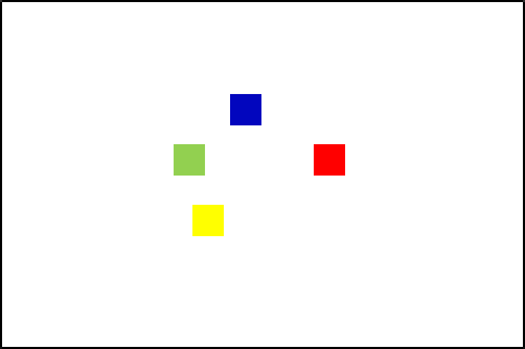

## Recognition Task with Continuous Stimuli

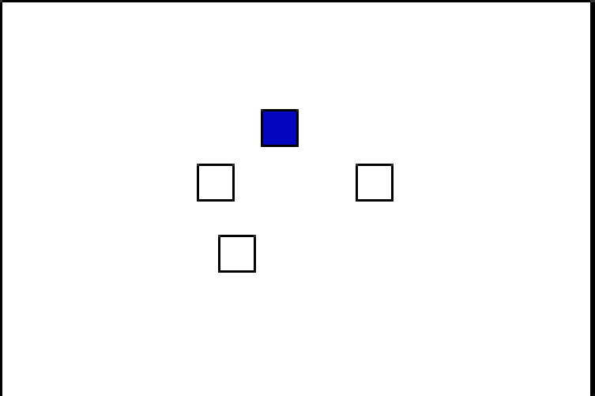

## Recognition Task with Continuous Stimuli

Probes:

1. Positive
   - sampled around the color of the target
   - "No Change"
2. Intrusion
3. New

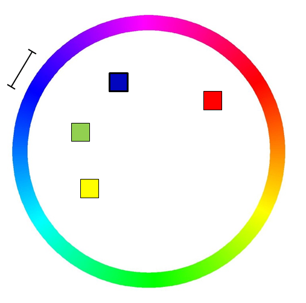

## Recognition Task with Continuous Stimuli

Probes:

1. Positive
2. Intrusion
   - sampled from the color of the non-target
   - "Change"
   - Internal change
3. New

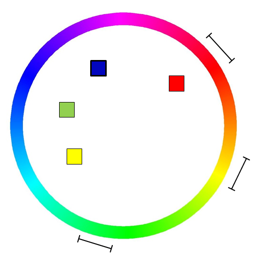

## Recognition Task with Continuous Stimuli

Probes:

1. Positive
2. Intrusion
3. New
   - sampled from the unused color
   - "Change"
   - External change

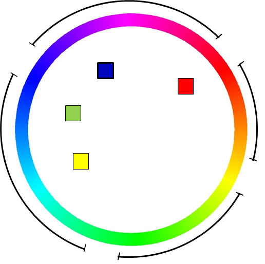

## Recognition Task with Continuous Stimuli

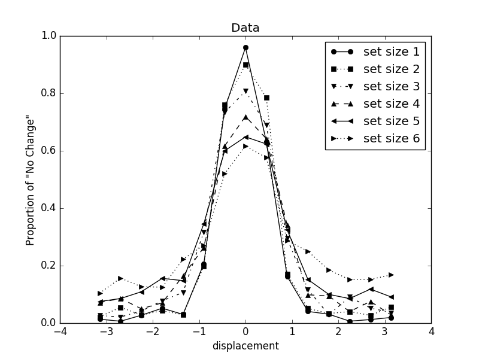

## Modeling

### IM + Bayes Inference Rule

#### IM:

- Interference Model
- Developed for continuous reconstruction task, aka, Colorwheel task.

#### Bayes Inference Rule:

- Was implemented to Slot-averaging and Variable Precision model by Keshvari, van den Berg, & Ma (2013).
- The IM version is developed by Klaus and Wei Ji Ma.

## Inference Rule

The one and only equation:

\[ \begin{align*} d &= log \left [\frac{p(C=1|x, \varphi )}{p(C=0|x, \varphi )} \right ]\\ &= log \left [\frac{p(x, \varphi |C=1)}{p(x, \varphi |C=0)} \right ]\\ &= \text{BLACK MAGIC}\\ &=-log\left \{ 2\pi \left [ p(S_1)D(x;\varphi ) + (1-p(S_1))\frac{1}{2\pi} \right ] \right \} \end{align*} \]

\(C=1\): "change"; \(C=0\): "no change";

\(x\): retrieved instance at probed location;

\(\varphi\): probe;

\(p(S_1)\): proportion of activation from the item at the probed location.

## Inference Rule

The one and only equation:

\[ \begin{align*} d &= log \left [\frac{p(C=1|x, \varphi )}{p(C=0|x, \varphi )} \right ]\\ &= log \left [\frac{p(x, \varphi |C=1)}{p(x, \varphi |C=0)} \right ]\\ &= \text{BLACK MAGIC}\\ &=-log\left \{ 2\pi \left [ p(S_1)D(x;\varphi ) + (1-p(S_1))\frac{1}{2\pi} \right ] \right \} \end{align*} \]

Assumptions:

1. Participants are aware of the probability of recalling an item.
2. The probe in the change response is assumed as an uniformly distributed on the color wheel.

## Simulation

### Data

### Vanilla IMBayes

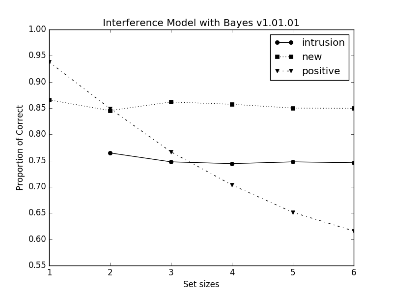

- Set size 2.
- Intrusion probes.

## Simulation

### Data

### Normalized Distance IMBayes

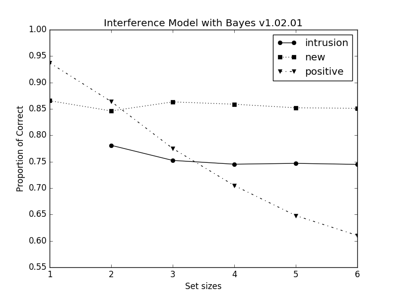

- Slightly better, but just slightly.
- Model Name: Interference Model with Bayes Vanilla, AIC: 10246.176342182818
- Model Name: Interference Model with Bayes Normalized Distance, AIC: 10215.852985319874

## Conclusion

The addon seems to work.

- The model CAN predit the right pattern of set-size effect.
- The major misfit comes from set-size 2 and intrusion probe.

## Few more goats later

Change the assumption

- The probe in the change response is assumed as an uniformly distributed on the color wheel.

to

- The probe in the change response is assumed as an uniformly distributed on the color wheel 50% of the time and selected from non-target color 50% of the time.

## Few more goats later

### Data

### IMBayes Swap

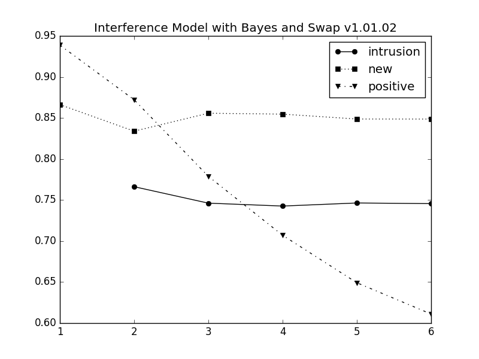

- ……
- Model Name: Interference Model with Bayes and Swap v1.01.02, AIC: 10228.08080848

## Thanks for your attention

## Reaction Time

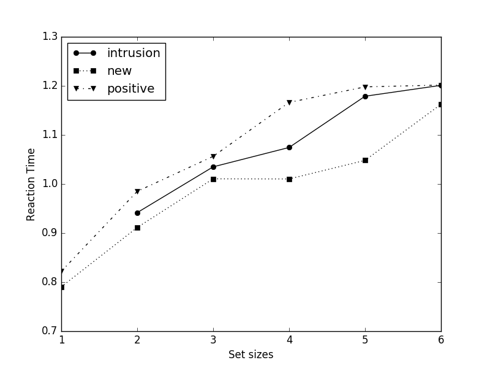

## Simulated Response Distribution

### Vanilla IMBayes

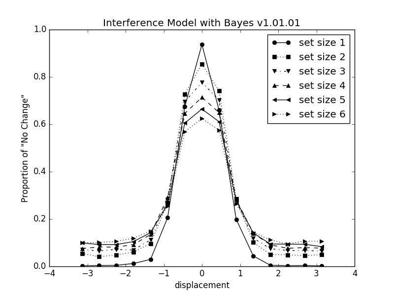

### Normalized Distance IMBayes

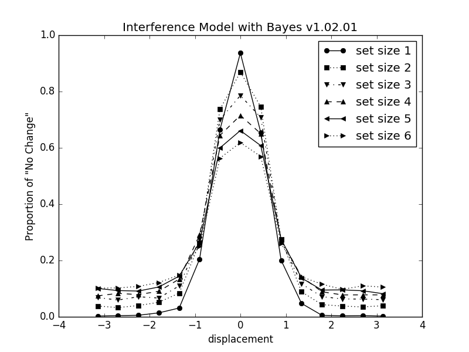